# Project: Medical Appointment No Shows Data Analysis

- Introduction
- Data Wrangling
- Exploratory Data Analysis
- Conclusions

## Introduction

In this project we'll be analyzing the No-show appointments dataset which can be found [here](https://www.kaggle.com/joniarroba/noshowappointments). In particular, we'll be interested in finding trends among patients who showed up for their medical appointments, and how they differed from those patients who did not. The dataset contains the following columns which are described as follows:

> - PatientId = Identification of a patient
> - AppointmentID = Identification of each appointment
> - Gender = Male or Female
> - ScheduledDay = The day someone called or registered for the appointment
> - AppointmentDay = The day of the actual appointment
> - Age = How old is the patient
> - Neighbourhood = Where the appointment takes place
> - Scholarship = True of False
> - Hipertension = True or False
> - Diabetes = True or False
> - Alcoholism = True or False
> - Handcap = The number of disabilites a patient has
> - SMS_received = True or False
> - No-show = True or False

From these factors we will determine which have the most impact on a patient showing up for their scheduled appointment. Here are some relevant questions we'll be answering:

1. Does age determine no show rates?
2. Does receiving an SMS notification affect no show rates?
3. Does the wait time between scheduling and the actual appointment determine no show rates?
4. Does gender affect no show rates?
5. Does having a disability affect no show rates?
6. Does having a pre-existing condition such as hypertension, diabetes and/or alcoholism determine no show rates?

Let's begin by importing all required packages.

```python
import numpy as np
import pandas as pd
import matplotlib.pyplot as plt
%matplotlib inline
import seaborn as sns
sns.set_style('darkgrid')
```

## Data Wrangling

### General Properties

We'll be loading the dataset directly from the website since it's already in CSV format.

```python
data_url = "https://d17h27t6h515a5.cloudfront.net/topher/2017/October/59dd2e9a_noshowappointments-kagglev2-may-2016/noshowappointments-kagglev2-may-2016.csv"
df = pd.read_csv(data_url)
df.head()
```

|  | PatientId | AppointmentID | Gender | ScheduledDay | AppointmentDay | Age | Neighbourhood | Scholarship | Hipertension | Diabetes | Alcoholism | Handcap | SMS_received | No-show |
| --- | --- | --- | --- | --- | --- | --- | --- | --- | --- | --- | --- | --- | --- | --- |
| 0 | 2.987250e+13 | 5642903 | F | 2016-04-29T18:38:08Z | 2016-04-29T00:00:00Z | 62 | JARDIM DA PENHA | 0 | 1 | 0 | 0 | 0 | 0 | No |
| 1 | 5.589978e+14 | 5642503 | M | 2016-04-29T16:08:27Z | 2016-04-29T00:00:00Z | 56 | JARDIM DA PENHA | 0 | 0 | 0 | 0 | 0 | 0 | No |
| 2 | 4.262962e+12 | 5642549 | F | 2016-04-29T16:19:04Z | 2016-04-29T00:00:00Z | 62 | MATA DA PRAIA | 0 | 0 | 0 | 0 | 0 | 0 | No |
| 3 | 8.679512e+11 | 5642828 | F | 2016-04-29T17:29:31Z | 2016-04-29T00:00:00Z | 8 | PONTAL DE CAMBURI | 0 | 0 | 0 | 0 | 0 | 0 | No |
| 4 | 8.841186e+12 | 5642494 | F | 2016-04-29T16:07:23Z | 2016-04-29T00:00:00Z | 56 | JARDIM DA PENHA | 0 | 1 | 1 | 0 | 0 | 0 | No |

### Cleaning Column Labels

Before exploring the dataset further, let's clean up the column labels and convert everything to lowercase for consistency. We'll also be renaming the **Hipertension** and **Handcap** columns which are misspelled.

```python
# rename Hipertension to Hypertension
df.rename(columns={'Hipertension':'Hypertension'}, inplace=True)
# rename Handcap to Disability
df.rename(columns={'Handcap':'Disability'}, inplace=True)
# replace dashes with underscores and convert everything to lowercase
df.rename(columns=lambda x: x.strip().lower().replace("-", "_"), inplace=True)
# confirm changes
df.head(1)
```

|  | patientid | appointmentid | gender | scheduledday | appointmentday | age | neighbourhood | scholarship | hypertension | diabetes | alcoholism | disability | sms_received | no_show |
| --- | --- | --- | --- | --- | --- | --- | --- | --- | --- | --- | --- | --- | --- | --- |
| 0 | 2.987250e+13 | 5642903 | F | 2016-04-29T18:38:08Z | 2016-04-29T00:00:00Z | 62 | JARDIM DA PENHA | 0 | 1 | 0 | 0 | 0 | 0 | No |

Much better! Next, let's look at the dimensions of this dataset.

```python
df.shape
```

```
(110527, 14)
```

We have over 100k rows and 14 columns. Let's now check the datatype of these columns.

```python
df.dtypes
```

```
patientid         float64
appointmentid       int64
gender             object
scheduledday       object
appointmentday     object
age                 int64
neighbourhood      object
scholarship         int64
hypertension        int64
diabetes            int64
alcoholism          int64
disability          int64
sms_received        int64
no_show            object
dtype: object
```

It looks like **scheduledday**, **appointmentday** and **no_show** are all string variables. Let's confirm.

```python
type(df['scheduledday'][0]), type(df['appointmentday'][0]), type(df['no_show'][0])
```

```
(str, str, str)
```

All right, we'll need to change the datatypes for these 3 variables later. Next, let's look at some useful statistics.

```python
df.describe()
```

|  | patientid | appointmentid | age | scholarship | hypertension | diabetes | alcoholism | disability | sms_received |
| --- | --- | --- | --- | --- | --- | --- | --- | --- | --- |
| count | 1.105270e+05 | 1.105270e+05 | 110527.000000 | 110527.000000 | 110527.000000 | 110527.000000 | 110527.000000 | 110527.000000 | 110527.000000 |
| mean | 1.474963e+14 | 5.675305e+06 | 37.088874 | 0.098266 | 0.197246 | 0.071865 | 0.030400 | 0.022248 | 0.321026 |
| std | 2.560949e+14 | 7.129575e+04 | 23.110205 | 0.297675 | 0.397921 | 0.258265 | 0.171686 | 0.161543 | 0.466873 |
| min | 3.921784e+04 | 5.030230e+06 | -1.000000 | 0.000000 | 0.000000 | 0.000000 | 0.000000 | 0.000000 | 0.000000 |
| 25% | 4.172614e+12 | 5.640286e+06 | 18.000000 | 0.000000 | 0.000000 | 0.000000 | 0.000000 | 0.000000 | 0.000000 |
| 50% | 3.173184e+13 | 5.680573e+06 | 37.000000 | 0.000000 | 0.000000 | 0.000000 | 0.000000 | 0.000000 | 0.000000 |
| 75% | 9.439172e+13 | 5.725524e+06 | 55.000000 | 0.000000 | 0.000000 | 0.000000 | 0.000000 | 0.000000 | 1.000000 |
| max | 9.999816e+14 | 5.790484e+06 | 115.000000 | 1.000000 | 1.000000 | 1.000000 | 1.000000 | 4.000000 | 1.000000 |

From here we can quickly infer that the average age of patients is 37, around 10% have scholarships, 20% have hypertension, 7% are diabetic, 3% suffer from alcoholism, 2% have a disability and 32% were sent an SMS reminder about the appointment. The data also shows the minimum age as -1 instead of 0. Could this be an error? Let's look at all rows where age is -1.

```python
df.query('age == -1')
```

|  | patientid | appointmentid | gender | scheduledday | appointmentday | age | neighbourhood | scholarship | hypertension | diabetes | alcoholism | disability | sms_received | no_show |
| --- | --- | --- | --- | --- | --- | --- | --- | --- | --- | --- | --- | --- | --- | --- |
| 99832 | 4.659432e+14 | 5775010 | F | 2016-06-06T08:58:13Z | 2016-06-06T00:00:00Z | -1 | ROMÃO | 0 | 0 | 0 | 0 | 0 | 0 | No |

Since it's only 1 row let's just delete this sample.

```python
# delete row where age is -1
df.drop(df.query('age == -1').index, inplace=True)
# confirm change
df.query('age == -1')
```

|  | patientid | appointmentid | gender | scheduledday | appointmentday | age | neighbourhood | scholarship | hypertension | diabetes | alcoholism | disability | sms_received | no_show |
| --- | --- | --- | --- | --- | --- | --- | --- | --- | --- | --- | --- | --- | --- | --- |

Moving on, let's check which features have missing values.

```python
df.isnull().sum()
```

```
patientid         0
appointmentid     0
gender            0
scheduledday      0
appointmentday    0
age               0
neighbourhood     0
scholarship       0
hypertension      0
diabetes          0
alcoholism        0
disability        0
sms_received      0
no_show           0
dtype: int64
```

Good, none of the columns have null values. We'll be checking for duplicated rows next.

```python
df.duplicated().sum()
```

```
0
```

There aren't any duplicated rows. How fortunate, this will save us a few steps. We'll move on then to cleaning the data.

### Data Cleaning

Let's start by dropping those columns we won't be using in this analysis. Those are **patientid**, **appointmentid**, **neighbourhood** and **scholarship**.

```python
# drop extraneous columns
df.drop(['patientid', 'appointmentid', 'neighbourhood', 'scholarship'], axis=1, inplace=True)
# confirm changes
df.head(1)
```

|  | gender | scheduledday | appointmentday | age | hypertension | diabetes | alcoholism | disability | sms_received | no_show |
| --- | --- | --- | --- | --- | --- | --- | --- | --- | --- | --- |
| 0 | F | 2016-04-29T18:38:08Z | 2016-04-29T00:00:00Z | 62 | 1 | 0 | 0 | 0 | 0 | No |

Next, let's work on the **scheduledday** and **appointmentday** columns. As mentioned earlier, these need to be converted from string to date format.

```python
# convert scheduledday and appointmentday columns from string to date format and drop the time portion
df['scheduledday'] = pd.to_datetime(df['scheduledday']).dt.date
df['appointmentday'] = pd.to_datetime(df['appointmentday']).dt.date
# confirm changes
type(df['scheduledday'][0]), type(df['appointmentday'][0])
```

```
(datetime.date, datetime.date)
```

Since one of the questions for our analysis has to do with the wait times between scheduling and appointment dates, let's add a new column called **wait_time** to our dataset.

```python
# calculate and add a new column for the wait time
df['wait_time'] = (df.appointmentday - df.scheduledday).dt.days
# confirm change
df.head()
```

|  | gender | scheduledday | appointmentday | age | hypertension | diabetes | alcoholism | disability | sms_received | no_show | wait_time |
| --- | --- | --- | --- | --- | --- | --- | --- | --- | --- | --- | --- |
| 0 | F | 2016-04-29 | 2016-04-29 | 62 | 1 | 0 | 0 | 0 | 0 | No | 0 |
| 1 | M | 2016-04-29 | 2016-04-29 | 56 | 0 | 0 | 0 | 0 | 0 | No | 0 |
| 2 | F | 2016-04-29 | 2016-04-29 | 62 | 0 | 0 | 0 | 0 | 0 | No | 0 |
| 3 | F | 2016-04-29 | 2016-04-29 | 8 | 0 | 0 | 0 | 0 | 0 | No | 0 |
| 4 | F | 2016-04-29 | 2016-04-29 | 56 | 1 | 1 | 0 | 0 | 0 | No | 0 |

Let's look at some statistics for the new column.

```python
df.wait_time.describe()
```

```
count    110526.000000
mean         10.183794
std          15.255034
min          -6.000000
25%           0.000000
50%           4.000000
75%          15.000000
max         179.000000
Name: wait_time, dtype: float64
```

Looks good, but wait! Why is the lowest value -6 instead of 0? This could mean some dates were entered incorrectly. Let's look at those rows where **wait_time** is a negative number to decide how to address this.

```python
df.query('wait_time < 0')
```

|  | gender | scheduledday | appointmentday | age | hypertension | diabetes | alcoholism | disability | sms_received | no_show | wait_time |
| --- | --- | --- | --- | --- | --- | --- | --- | --- | --- | --- | --- |
| 27033 | M | 2016-05-10 | 2016-05-09 | 38 | 0 | 0 | 0 | 1 | 0 | Yes | -1 |
| 55226 | F | 2016-05-18 | 2016-05-17 | 19 | 0 | 0 | 0 | 1 | 0 | Yes | -1 |
| 64175 | F | 2016-05-05 | 2016-05-04 | 22 | 0 | 0 | 0 | 0 | 0 | Yes | -1 |
| 71533 | F | 2016-05-11 | 2016-05-05 | 81 | 0 | 0 | 0 | 0 | 0 | Yes | -6 |
| 72362 | M | 2016-05-04 | 2016-05-03 | 7 | 0 | 0 | 0 | 0 | 0 | Yes | -1 |

Okay, so that brought up only 5 samples. We'll just attribute this to data entry error and drop the 5 rows in question.

```python
# delete rows where wait_time is negative
df.drop(df.query('wait_time < 0').index, inplace=True)
# confirm changes
df.query('wait_time < 0')
```

|  | gender | scheduledday | appointmentday | age | hypertension | diabetes | alcoholism | disability | sms_received | no_show | wait_time |
| --- | --- | --- | --- | --- | --- | --- | --- | --- | --- | --- | --- |

Lastly, we'll be converting the **no_show** column from string to boolean (0,1) to allow numeric functions to be performed on this variable.

```python
df.no_show.unique()
```

```
array(['No', 'Yes'], dtype=object)
```

```python
df.no_show = df.no_show.map(dict(Yes=1, No=0))
# confirm changes
df.no_show.unique()
```

```
array([0, 1], dtype=int64)
```

After converting this column we can now compute the average no show rate for all samples.

```python
df.no_show.mean()
```

```
0.2018982817745044
```

It appears around 20% of patients miss their apppointments. That concludes the trimming and cleaning portion of our analysis. Now it's time to explore the data and answer the questions we posed earlier.

## Exploratory Data Analysis

So why do 20% of patients miss their scheduled appointments? What factors should we consider when making a prediction? On to the questions!

### Research Question 1 (Does age determine no show rates?)

Let's start by comparing the average age of patients who showed up to their appointments versus those who didn't.

```python
# patients who showed up to their appointments
df[df.no_show == 0].age.mean()
```

```
37.790504154999034
```

```python
# patients who missed their appointments
df[df.no_show == 1].age.mean()
```

```
34.31787218786412
```

The average age of those who showed up is 37 while for those who missed their appointments the average is 34. Not much difference there. But let's group the patients by age range for a more detailed analysis.

```python
# view the min, 25%, 50%, 75% and max age values
df.age.describe()
```

```
count    110521.000000
mean         37.089386
std          23.109885
min           0.000000
25%          18.000000
50%          37.000000
75%          55.000000
max         115.000000
Name: age, dtype: float64
```

```python
# create bins for age ranges
bin_edges = [0, 18, 37, 55, 115]
bin_names = ['0-18', '19-37', '38-55', '56+']
out = pd.cut(df.age, bin_edges, labels=bin_names, include_lowest = True)
```

```python
# group patients by age range and get the average no show rate for each
df.groupby(out).no_show.mean()
```

```
age
0-18     0.219851
19-37    0.235320
38-55    0.195280
56+      0.156419
Name: no_show, dtype: float64
```

Let's create a bar chart to express these results in a visual. As our bar chart will be customized, it would be best to place the code in a function for later reusability.

```python
# define bar_plot function
def bar_plot(locations, heights, labels, colors, title, xlabel, ylabel, xoff, yoff):
    plt.figure(figsize=(12, 8))
    sns.set_context('talk')
    bars = plt.bar(locations, heights, tick_label=labels, color=colors)
    for bar in bars:
        yval = bar.get_height().round(1)
        plt.text(bar.get_x() + xoff, yval + yoff, yval)
    plt.title(title, pad=20)
    plt.xlabel(xlabel, labelpad=20)
    plt.ylabel(ylabel, labelpad=20);
```

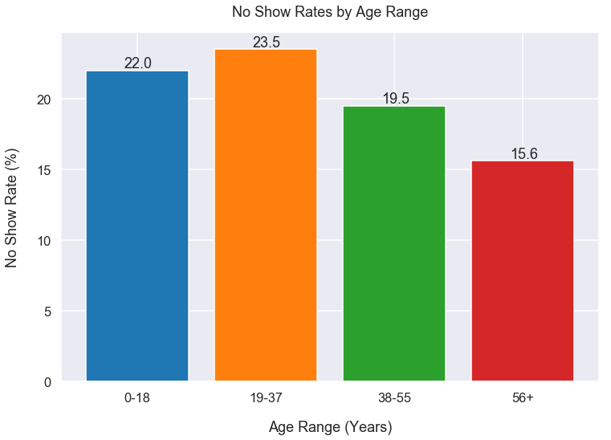

```python
# call bar_plot function
locations = [1, 2, 3, 4]
heights = df.groupby(out).no_show.mean().mul(100)
labels = bin_names
barcolors = ['C0', 'C1', 'C2', 'C3']
title = 'No Show Rates by Age Range'
xlabel = 'Age Range (Years)'
ylabel = 'No Show Rate (%)'

bar_plot(locations, heights, labels, barcolors, title, xlabel, ylabel, 0.3, 0.2)
```

Based on the plot it looks like older patients (56 and above) are least likely to miss their appointments with a no show rate of around 15%. This is followed by patients in their late 30s to early 50s with a no show rate of 19%. Infants, children and teens have the 2nd highest no show rate at 22%, while patients in their 20s and 30s top the chart and miss 23% of their appointments.

### Research Question 2 (Does receiving an SMS notification affect no show rates?)

If patients receive an SMS reminder prior to their appointment date, would they be more likely to show up? Let's compare the 2 groups of those who received an SMS notification and those who didn't.

```python
df.groupby('sms_received').no_show.mean()
```

```
sms_received
0    0.166980
1    0.275745
Name: no_show, dtype: float64
```

Let's convert this to a simple bar chart for quick visual analysis.

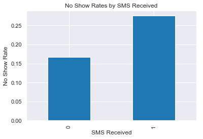

```python
sns.set_context('notebook')
df.groupby('sms_received').no_show.mean().plot(kind='bar');
plt.title('No Show Rates by SMS Received')
plt.xlabel('SMS Received')
plt.ylabel('No Show Rate');
```

It appears that those who receive SMS messages are actually much more likely to miss their appointments than those who do not. How can this be? Is there something wrong with the data? Digging further I found the answer [here](https://www.kaggle.com/joniarroba/noshowappointments/discussion/49775). Per the forum thread:

> SMS rates for people who make the appointment for the same day or within three days are exceptionally low - I also saw that no show rates are much lower in that time range. If we interpret the SMS column as an indication of an SMS being sent then it makes sense that hospitals would have a rule/system in place to not send SMS to people whose appointments are close to the date the appointment was scheduled.

Aha! We can look at the correlation between wait time and the number of SMS messages sent to confirm this. Also let's only consider wait times that are a week or shorter.

```python
df.query('wait_time < 8').groupby('wait_time').sms_received.sum()
```

```
wait_time
0       0
1       0
2       0
3     906
4    3054
5    2054
6    2684
7    2850
Name: sms_received, dtype: int64
```

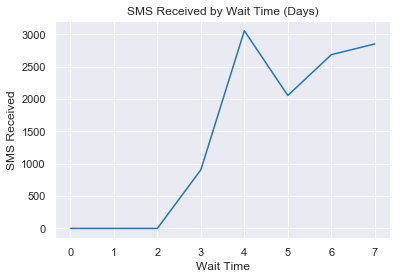

```python
# line chart visualization
sns.set_context('notebook')
data = df.query('wait_time < 8').groupby('wait_time').sms_received.sum()
plt.plot(data)
plt.title('SMS Received by Wait Time (Days)')
plt.xlabel('Wait Time')
plt.ylabel('SMS Received');
```

Bingo! For wait times less than 3 days the hospitals are not sending SMS reminders. Let's exclude these shorter wait times and run our analysis again. We can do this by creating a 2nd dataframe and exclude rows where wait times are less than 3 days, or conversely only include rows where wait times are greater than 2 days.

```python
df2 = df.query('wait_time > 2')
df2.groupby('sms_received').no_show.mean()
```

```
sms_received
0    0.326949
1    0.275745
Name: no_show, dtype: float64
```

Below is our final bar chart

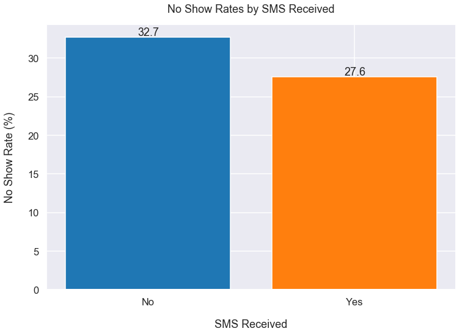

```python
locations = [1, 2]
heights = df2.groupby('sms_received').no_show.mean().mul(100)
labels = ['No', 'Yes']
barcolors = ['C0', 'C1']
title = 'No Show Rates by SMS Received'
xlabel = 'SMS Received'
ylabel = 'No Show Rate (%)'

bar_plot(locations, heights, labels, barcolors, title, xlabel, ylabel, 0.35, 0.2)
```

After the data cleanup we can now see that patients who didn't receive an SMS reminder are 5% more likely to miss their appointment than those who did.

### Research Question 3 (Does the wait time between scheduling and the actual appointment determine no show rates?)

For this question let's begin our analysis by looking at the correlation between wait times and no show rates, expressing the result as a line chart visual.

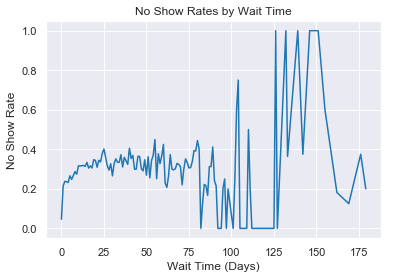

```python
sns.set_context('notebook')
data = df.groupby('wait_time').no_show.mean()
plt.plot(data)
plt.title('No Show Rates by Wait Time')
plt.xlabel('Wait Time (Days)')
plt.ylabel('No Show Rate');
```

Hmm, it seems longer waiting periods do result in more no shows, but the visualization is far from ideal. Let's switch to a bar chart and utilize groupings instead.

```python
# view the min, 25%, 50%, 75% and max wait time values
df.wait_time.describe()
```

```
count    110521.000000
mean         10.184345
std          15.255153
min           0.000000
25%           0.000000
50%           4.000000
75%          15.000000
max         179.000000
Name: wait_time, dtype: float64
```

```python
# create bins for wait times
bin_edges = [-np.inf, 0, 7, 14, 31, 179]
bin_names = ['0', '1-7', '8-14', '15-31', '32+']
out = pd.cut(df.wait_time, bin_edges, labels=bin_names, include_lowest = True)
```

```python
# group by wait time periods and get the average no show rate for each
df.groupby(out).no_show.mean()
```

```
wait_time
0        0.046471
1-7      0.241479
8-14     0.304699
15-31    0.325944
32+      0.330208
Name: no_show, dtype: float64
```

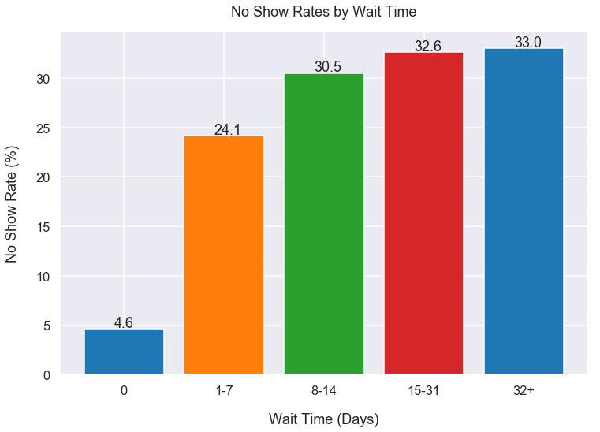

```python
# create a bar chart for visual analysis
locations = [1, 2, 3, 4, 5]
heights = df.groupby(out).no_show.mean().mul(100)
labels = bin_names
barcolors = ['C0', 'C1', 'C2', 'C3']
title = 'No Show Rates by Wait Time'
xlabel = 'Wait Time (Days)'
ylabel = 'No Show Rate (%)'

bar_plot(locations, heights, labels, barcolors, title, xlabel, ylabel, 0.3, 0.2)
```

This looks much better and we can clearly see a higher rate of missed appoinments as the waiting period increases.

### Research Question 4 (Does gender affect no show rates?)

This next analysis should be fairly straightforward. We can simply group the no show rates by gender and plot a bar chart based off the results.

```python
df.groupby('gender').no_show.mean()
```

```
gender
F    0.203115
M    0.199638
Name: no_show, dtype: float64
```

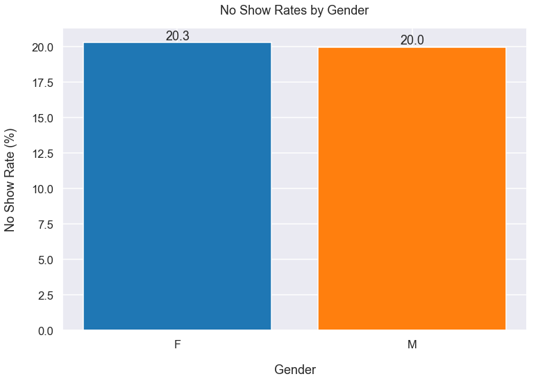

```python
locations = [1, 2]
heights = df.groupby('gender').no_show.mean().mul(100)
labels = ['F', 'M']
barcolors = ['C0', 'C1']
title = 'No Show Rates by Gender'
xlabel = 'Gender'
ylabel = 'No Show Rate (%)'

bar_plot(locations, heights, labels, barcolors, title, xlabel, ylabel, 0.35, 0.2)
```

Here we can see that the rate of no shows are practically identical across genders. Let's move on.

### Research Question 5 (Does having a disability affect no show rates?)

To answer this question, let's divide the dataset into 2 groups. One group will be patients with no disabilities and the other will be for those who have 1 or more. We can do this by creating masks for each group.

```python
# create masks for disability
no_disability = df.disability == 0
has_disability = df.disability > 0
```

Now let's compare the average no show rates for each group and plot the results.

```python
df.no_show[no_disability].mean()
```

```
0.20233279769490775
```

```python
df.no_show[has_disability].mean()
```

```
0.18088432335864224
```

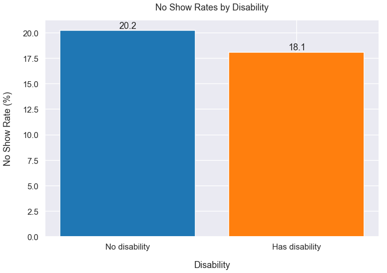

```python
locations = [1, 2]
a = df.no_show[no_disability].mean() * 100
b = df.no_show[has_disability].mean() * 100
heights =[a, b]
labels = ['No disability', 'Has disability']
barcolors = ['C0', 'C1']
title = 'No Show Rates by Disability'
xlabel = 'Disability'
ylabel = 'No Show Rate (%)'

bar_plot(locations, heights, labels, barcolors, title, xlabel, ylabel, 0.35, 0.2)
```

It appears that patients with disabilities are 2% less likely to miss their scheduled appointments.

### Research Question 6 (Does having a pre-existing condition such as hypertension, diabetes and/or alcoholism determine no show rates?)

For the final question in our analysis, let's create 4 groups. Group A will be patients with no pre-existing conditions, group B will be those who have hypertension, and so on. Of course some patients may have more than one condition but we'll be sticking with the 4 groups to keep things simple.

Let's create masks for each pre-existing condition.

```python
none = (df.hypertension == False) & (df.diabetes == False) & (df.alcoholism == False)
hypertension = df.hypertension == True
diabetes = df.diabetes == True
alcoholism = df.alcoholism == True
```

We can then filter the data using these masks and obtain the average no show rate for each group.

```python
df.no_show[none].mean()
```

```
0.20904742925468314
```

```python
df.no_show[hypertension].mean()
```

```
0.17301958625751113
```

```python
df.no_show[diabetes].mean()
```

```
0.18003273322422259
```

```python
df.no_show[alcoholism].mean()
```

```
0.20148809523809524
```

And lastly plot the results in a bar chart.

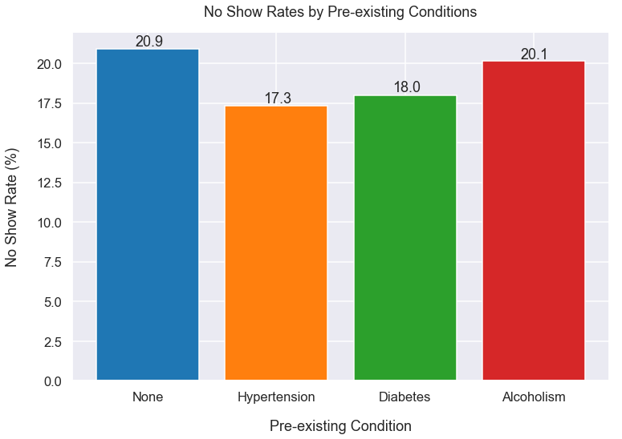

```python
locations = [1, 2, 3, 4]
a = df.no_show[none].mean() * 100
b = df.no_show[hypertension].mean() * 100
c = df.no_show[diabetes].mean() * 100
d = df.no_show[alcoholism].mean() * 100
heights =[a, b, c, d]
labels = ['None', 'Hypertension', 'Diabetes', 'Alcoholism']
barcolors = ['C0', 'C1', 'C2', 'C3']
title = 'No Show Rates by Pre-existing Conditions'
xlabel = 'Pre-existing Condition'
ylabel = 'No Show Rate (%)'

bar_plot(locations, heights, labels, barcolors, title, xlabel, ylabel, 0.3, 0.2)
```

From the above we see that patients with hypertension and/or diabetes are 2-3% less likely to miss their appointments, while alcoholism has little to no impact on the no show rate.

## Conclusions

Below is the summary of our findings. As a reminder the average no show rate for all patients is 20%.

**Age** - Older patients (56 and above) are least likely to miss their appointments, having only a 15% no show rate compared to the average which is 20%. Next are patients aged 38-55 with a 19% no show rate which is still better than average. Younger patients aged 0-18 are more likely to miss their appointments (22% vs the 20% average). And finally patients between 19-37 years old have the highest no show rate at 23%.

**SMS Received** - Patients who received SMS notifications were 5% less likely to miss their appointments than those who did not (27% vs 32% no show). Interestingly enough both figures are higher than the general average. Our analysis was limited by having to drop some samples so this may account for the disparity.

**Wait Time** - There is a direct correlation between the waiting period and the rate of no shows. As the wait time increases, so does the likelihood of missed appointments. Same date appointments have the lowest no show rate at 4%. From there up to a week the no show rate increases to 24%, after 2 weeks 33% of patients miss their appointments.

**Gender** - Our analysis shows this variable had practically no impact on the rate of missed appointments.

**Disability** - Persons with disabilities are 2% less likely to miss their appointments compared to the average.

**Pre-existing condition** - Patients with hypertension or diabetes are less likely to miss their appointments compared to the average by a difference of 3% and 2% respectively. Meanwhile alcoholism doesn't seem to play a factor in the no show rate. But keep in mind we did not factor in patients with 2 or more conditions so this limits our analysis.

Out of all the variables we explored, the most impactful were **Wait time**, **Age** and **SMS Received**, in that order. Those 3 factors are what we should consider when predicting if a patient makes their scheduled appointment. To be clear, there were limitations to our analysis. We did not include scholarship and neighborhood in our observations. Nor did we use more advanced statistical methods as that is beyond the scope of this project. That being said, we can end the report with a fair amount of confidence in our methodology and in the accuracy of our findings.